# PART II - DATA EXPLANATORY ON EMPLOYEE ATTRITION

## by Awah Mary Aporiyoore

## Dataset Overview

The chosen dataset for this project is the "Employee Attrition" dataset which was obtained from kaggle.com.

This dataset includes information about employees within a specific department, their educational fields, their total working years, total working hours, attrition among others.

The aim of this project is to identify the factors that causes employee attrition within a department.

## Investigation Overview

The overall goal for this presentation is to showcase the possible causes of an Employee Attrition.

The criteria for this is to analyse the data against the Attrition Count, Attrition Per Gender, Performance Rating, Job Involvement, Monthly Income and Relationship Satisfaction.

In the end, the visualizations will highlight the following:

It was quite suprising to find that Relationship Satisfaction was not one of the cause of employee Attrition.

### VISUALIZATION 1

This first visualization seeks to identify the number of attrition within the dataset.

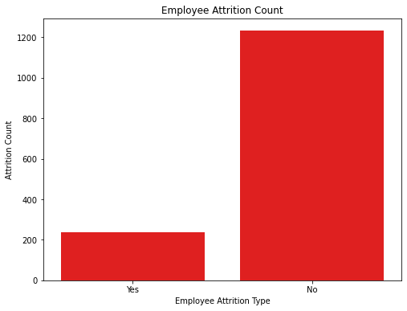

#### OBSERVATION

Based on the visualization produced above, the attrition count for "Yes" is 237 while the attrition count for "No" is 1233. Therefore, there is a low employee attrition.

Thus bringing us to the next visualization

### VISUALIZATION 2

#### Question: What is the Attrition Count Per Gender?

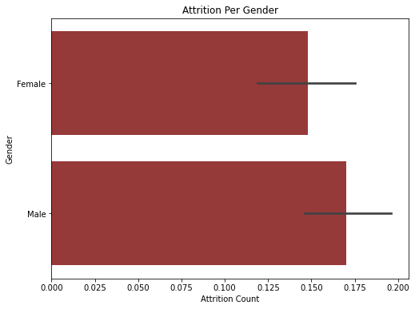

### OBSERVATION

Based on the visualization depicted above, Males have a higher attrition as compared to females.

### VISUALIZATION 3

This next visualization seeks to answer the question: 'Could their level of Job Involvement cause their attrition?'

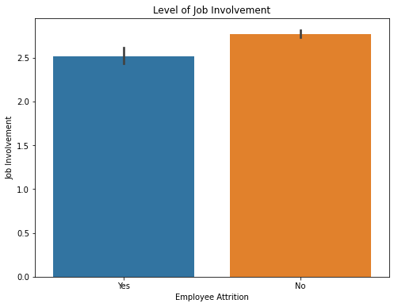

### OBSERVATION

The bar plot above confirms that Employees with Yes as their attrition have a lower Job Involvement.

### VISUALIZATION 4

This next visualization seeks to answer the question: 'Could their Performance Rating cause their attrition?'

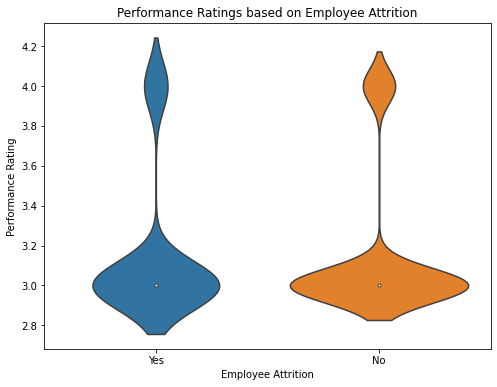

### VISUALIZATION 5

This next visualization seeks to answer the question: 'Could their Income cause their attrition?'

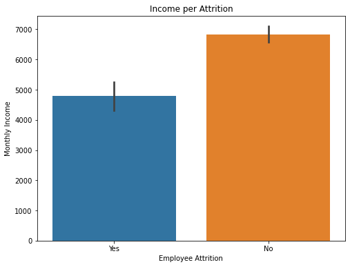

### OBSERVATION

The bar plot Above confirms that Employees with Yes as their attrition have a receives a lower Montly Income.

### VISUALIZATION 6

This next visualization seeks to answer the question: 'Does the relationship satisfaction affects the attrition.'

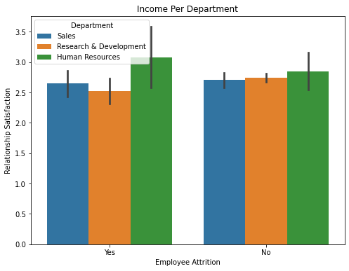

### VISUALIZATION 7

Could there be a correlation between the 2?

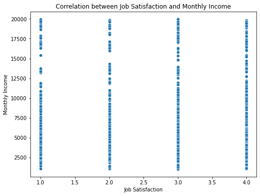

### OBSERVATION

Based on the plot above, there seem to be no linear relationship between the job satisfaction and monthly income

### VISUALIZATION 8

This final visualization to identify is the cause for employee attrition could be the distance from their home to work

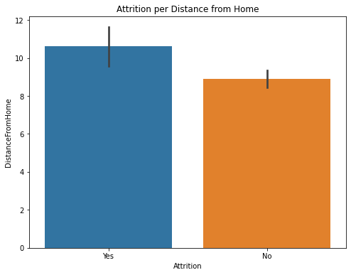

### OBSERVATION

Based on the plot above, employees with Yes as their attrition live farther from work